# lab9

zimeng

2019/3/14

```r
yield <- read.csv('https://raw.githubusercontent.com/OscarFHC/EAS538_2018/master/Week9_MultipleReg/yielddata.csv')
head(yield)
```

```
##           State   District    Yield Canal_Dist Irrigated_Per  Literate
## 1 Uttar Pradesh      Unnao 2965.788  8.6252015     1.0000000 0.1739130
## 2 Uttar Pradesh   Fatehpur 3248.265  2.5355166     1.0000000 0.4814490
## 3         Bihar Aurangabad 2538.736  0.7909722     0.4166492 0.4355878
## 4 Uttar Pradesh   Ghazipur 3173.908  7.4172259     0.6296039 0.4564417
## 5 Uttar Pradesh      Kheri 2961.298  0.9256326     1.0000000 0.5017544
## 6 Uttar Pradesh  Kaushambi 3087.786 13.8004294     0.6902360 0.2195270
##   Cultivator    AgLabor     Rain Temperature Elevation  SowDate
## 1 0.25585284 0.01170569 223.8928    12.81596       116 4.738676
## 2 0.08881098 0.05316973 235.6471    12.54157       118 4.321697
## 3 0.08856683 0.08776167 309.5277    14.09054       112 4.117498
## 4 0.08036810 0.04171779 314.6497    13.92136        72 3.293600
## 5 0.16140351 0.08947368 310.8220    11.64079       152 6.461493
## 6 0.08671922 0.02850212 255.1154    12.97836       105 4.751297
```

## recap

```r
unimodel <- lm(Yield ~ Temperature, data = yield)
summary(unimodel)
```

```
##
## Call:
## lm(formula = Yield ~ Temperature, data = yield)
##
## Residuals:
##     Min      1Q  Median      3Q     Max
## -775.96 -191.99    5.34  202.63  733.14
##
## Coefficients:
##             Estimate Std. Error t value Pr(>|t|)
## (Intercept)  5531.24     168.46   32.83   <2e-16 ***
## Temperature  -186.43      13.38  -13.94   <2e-16 ***
## ---
## Signif. codes:  0 '***' 0.001 '**' 0.01 '*' 0.05 '.' 0.1 ' ' 1
##
## Residual standard error: 290.9 on 198 degrees of freedom
## Multiple R-squared:  0.4951, Adjusted R-squared:  0.4926
## F-statistic: 194.2 on 1 and 198 DF,  p-value: < 2.2e-16
```

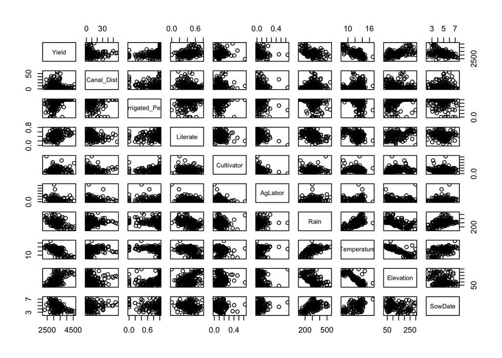

```r
pairs(yield[,3:12])
```

```r
cor(yield[,3:12], use = 'complete.obs')
```

```
##                     Yield   Canal_Dist Irrigated_Per   Literate
## Yield          1.00000000 -0.100792366    0.37291308  0.3457707
## Canal_Dist    -0.10079237  1.000000000   -0.07972347 -0.2496504
## Irrigated_Per  0.37291308 -0.079723466    1.00000000  0.2509635
## Literate       0.34577067 -0.249650351    0.25096345  1.0000000
## Cultivator     0.02234091  0.065408774    0.05162662 -0.1369370
## AgLabor       -0.15816302 -0.001745039   -0.21556017 -0.1769701
## Rain          -0.46098180  0.132098845   -0.23158320 -0.3669876
## Temperature   -0.69818335  0.079179775   -0.42512905 -0.3725307
## Elevation      0.57367350 -0.044009816    0.36640038  0.3117005
## SowDate       -0.44594054  0.055231777   -0.08520842 -0.1669194
##                Cultivator      AgLabor        Rain Temperature   Elevation
## Yield          0.02234091 -0.158163024 -0.46098180 -0.69818335  0.57367350
## Canal_Dist     0.06540877 -0.001745039  0.13209885  0.07917977 -0.04400982
## Irrigated_Per  0.05162662 -0.215560168 -0.23158320 -0.42512905  0.36640038
## Literate      -0.13693696 -0.176970123 -0.36698760 -0.37253074  0.31170047
## Cultivator     1.00000000 -0.265589442 -0.05561866 -0.14538940  0.11161674
## AgLabor       -0.26558944  1.000000000  0.09390849  0.09030555  0.01043637
## Rain          -0.05561866  0.093908491  1.00000000  0.62937563 -0.56896820
## Temperature   -0.14538940  0.090305550  0.62937563  1.00000000 -0.87606076
## Elevation      0.11161674  0.010436371 -0.56896820 -0.87606076  1.00000000
## SowDate       -0.05514825  0.119925409  0.46630992  0.46552392 -0.31366412
##                   SowDate
## Yield         -0.44594054
## Canal_Dist     0.05523178
## Irrigated_Per -0.08520842
## Literate      -0.16691936
## Cultivator    -0.05514825
## AgLabor        0.11992541
## Rain           0.46630992
## Temperature    0.46552392
## Elevation     -0.31366412
## SowDate        1.00000000
```

```r
library(car)
library(carData)
vif(lm(Yield ~ Canal_Dist + Irrigated_Per + Literate + Cultivator + AgLabor + Rain + Temperature + Elevation + SowDate, data = yield))
```

```
##    Canal_Dist Irrigated_Per      Literate    Cultivator       AgLabor
##      1.079929      1.320238      1.392133      1.178451      1.231330
##          Rain   Temperature     Elevation       SowDate
##      1.874005      6.081935      4.742333      1.490840
```

# Exercise 1 (R code and outputs required)

## 1

**Using information that you just produced from the scatterplots, correlation table, and vif, are there any variables you are concerned about including together in the same linear model? In other words, which variables do you think would lead to multi-collinearity in your model? Why?** I worry about including these following variables together in the same linear model. Because they are too correlate.

temperature and elevation Rain and elevation temperature and rain

Correlation values of these variables are > 0.5. In the scatter plot, temperature and elevation, rain and elevation as well as temperature and rain seem to be related. The vif value of temperature is greater than 5.

## 2

**What are the two most correlated variables you see in the correlation table produced using cor? Please run two separate univariate models where Yield is your dependent variable and one of the two correlated variables is your predictor variable. Now run a multivariate regression with Yield as your dependent variable and both of your correlated variables as pedictor variables in the same model. Compare the beta coefficients you get for each of the two predictor variables in the univariate model and the multivariate model. Are they the same? Are they different? Why?**

temperature and elevation

```r
unimodel1 <- lm(Yield ~ Temperature, data = yield)
summary(unimodel1)
```

```
##
## Call:
## lm(formula = Yield ~ Temperature, data = yield)
##
## Residuals:
##     Min      1Q  Median      3Q     Max
## -775.96 -191.99    5.34  202.63  733.14
##
## Coefficients:
##             Estimate Std. Error t value Pr(>|t|)
## (Intercept)  5531.24     168.46   32.83   <2e-16 ***
## Temperature  -186.43      13.38  -13.94   <2e-16 ***
## ---
## Signif. codes:  0 '***' 0.001 '**' 0.01 '*' 0.05 '.' 0.1 ' ' 1
##
## Residual standard error: 290.9 on 198 degrees of freedom
## Multiple R-squared:  0.4951, Adjusted R-squared:  0.4926
## F-statistic: 194.2 on 1 and 198 DF,  p-value: < 2.2e-16
```

```r
unimodel2 <- lm(Yield ~ Elevation, data = yield)
summary(unimodel2)
```

```
##
## Call:
## lm(formula = Yield ~ Elevation, data = yield)
##
## Residuals:
##    Min     1Q Median     3Q    Max
## -804.6 -225.0   -6.9  195.9 1063.1
##
## Coefficients:
##              Estimate Std. Error t value Pr(>|t|)
## (Intercept) 2779.1943    50.2639  55.292   <2e-16 ***
## Elevation      3.4208     0.3582   9.551   <2e-16 ***
## ---
## Signif. codes:  0 '***' 0.001 '**' 0.01 '*' 0.05 '.' 0.1 ' ' 1
##
## Residual standard error: 338.7 on 198 degrees of freedom
## Multiple R-squared:  0.3154, Adjusted R-squared:  0.3119
## F-statistic: 91.22 on 1 and 198 DF,  p-value: < 2.2e-16
```

```r
multivariate <- lm(Yield ~ Temperature + Elevation, data = yield)
summary(multivariate)
```

```
##
## Call:
## lm(formula = Yield ~ Temperature + Elevation, data = yield)
##
## Residuals:
##     Min      1Q  Median      3Q     Max
## -786.95 -189.79    4.24  204.59  712.88
##
## Coefficients:
##              Estimate Std. Error t value Pr(>|t|)
## (Intercept) 5864.7319   367.2957  15.967  < 2e-16 ***
## Temperature -207.4310    24.5211  -8.459 6.02e-15 ***
## Elevation     -0.5760     0.5638  -1.022    0.308
## ---
## Signif. codes:  0 '***' 0.001 '**' 0.01 '*' 0.05 '.' 0.1 ' ' 1
##
## Residual standard error: 290.8 on 197 degrees of freedom
## Multiple R-squared:  0.4978, Adjusted R-squared:  0.4927
## F-statistic: 97.64 on 2 and 197 DF,  p-value: < 2.2e-16
```

In univariate models, beta coefficient of temperature is -186.43 and beta coefficient of elevation is 3.4208. In the multivariate model, beta coefficient of temperature is -207.4310 and beta coefficient of elevation is -0.5760. I think they are different. Because temperature and elevation are to related and lead to multi-collinearity.

## Exercise 2 (Some R code and outputs required)

```r
fullmod <- lm(Yield ~ Canal_Dist + Irrigated_Per + Literate + Cultivator + AgLabor + Rain + Temperature + Elevation + SowDate, data = yield)
```

```r
fullmod2 <- lm(Yield ~ Canal_Dist + Irrigated_Per + Literate + Cultivator + AgLabor + Temperature + SowDate, data = yield)
```

```r
smallmod <- lm(Yield ~ Canal_Dist + Irrigated_Per + Temperature + SowDate, data = yield)
```

```r
AIC(fullmod2)
```

```
## [1] 2275.772
```

```r
AIC(smallmod)
```

```
## [1] 2477.5
```

## 1

**Which model would you select considering the AIC values shown above?** fullmodel2, because it has a lowere AIC value.

## 2

**Please test the assumptions of normality and homoscedasticity of this model. Do you think there are problems with either normality or homoscedasticity of the residuals? Why or why not?**

**normality**

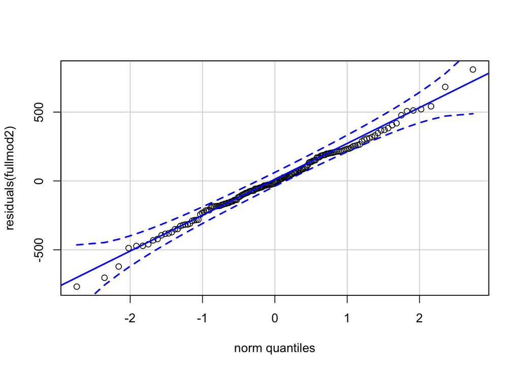

```r
qqPlot(residuals(fullmod2),id=FALSE)
```

```r
shapiro.test(residuals(fullmod2))
```

```
##
##  Shapiro-Wilk normality test
##
## data:  residuals(fullmod2)
## W = 0.99425, p-value = 0.7778
```

Most part of residuals fall within the dotted blue lines, and p-value is larger than 0.05. So the null hypothsis that errors are normally distributed is not rejected. Residuals are normally distributed.

**homoscedasticity**

```r
library(zoo)
library(car)
library(lmtest)
```

```r
bptest(fullmod2)
```

```
##
##  studentized Breusch-Pagan test
##
## data:  fullmod2
## BP = 19.046, df = 7, p-value = 0.008045
```

```r
ncvTest(fullmod2)
```

```
## Non-constant Variance Score Test
## Variance formula: ~ fitted.values
## Chisquare = 8.052352, Df = 1, p = 0.0045445
```

Both of these results show that our p-value is below 0.05, therefore we reject the null hypothesis of homoscedasticity, and our residuals are not homoscedastic.

## 3

**Please run this model (even if assumptions of normality or homoscedasticity are violated) and look at the summary table. Which variables are significant? How does the beta coefficient value of Temperature differ between the multivariate and univariate models? Why do you think that is?**

```r
fullmod2 <- lm(Yield ~ Canal_Dist + Irrigated_Per + Literate + Cultivator + AgLabor + Temperature + SowDate, data = yield)
summary(fullmod2)
```

```
##
## Call:
## lm(formula = Yield ~ Canal_Dist + Irrigated_Per + Literate +
##     Cultivator + AgLabor + Temperature + SowDate, data = yield)
##
## Residuals:
##     Min      1Q  Median      3Q     Max
## -767.29 -163.64   -7.71  187.66  808.98
##
## Coefficients:
##                Estimate Std. Error t value Pr(>|t|)
## (Intercept)   5194.7420   287.2336  18.085  < 2e-16 ***
## Canal_Dist      -0.7176     1.9378  -0.370   0.7117
## Irrigated_Per  132.1409    94.3785   1.400   0.1635
## Literate       131.4272   159.7811   0.823   0.4120
## Cultivator    -382.0980   261.5528  -1.461   0.1461
## AgLabor       -390.2264   284.9760  -1.369   0.1729
## Temperature   -142.9815    18.4862  -7.734 1.27e-12 ***
## SowDate        -54.7208    22.0343  -2.483   0.0141 *
## ---
## Signif. codes:  0 '***' 0.001 '**' 0.01 '*' 0.05 '.' 0.1 ' ' 1
##
## Residual standard error: 263.7 on 154 degrees of freedom
##   (38 observations deleted due to missingness)
## Multiple R-squared:  0.5335, Adjusted R-squared:  0.5123
## F-statistic: 25.16 on 7 and 154 DF,  p-value: < 2.2e-16
```

Temperature, and SowDate are significant.

```r
unimodel1 <- lm(Yield ~ Temperature, data = yield)
summary(unimodel1)
```

```
##
## Call:
## lm(formula = Yield ~ Temperature, data = yield)
##
## Residuals:
##     Min      1Q  Median      3Q     Max
## -775.96 -191.99    5.34  202.63  733.14
##
## Coefficients:
##             Estimate Std. Error t value Pr(>|t|)
## (Intercept)  5531.24     168.46   32.83   <2e-16 ***
## Temperature  -186.43      13.38  -13.94   <2e-16 ***
## ---
## Signif. codes:  0 '***' 0.001 '**' 0.01 '*' 0.05 '.' 0.1 ' ' 1
##
## Residual standard error: 290.9 on 198 degrees of freedom
## Multiple R-squared:  0.4951, Adjusted R-squared:  0.4926
## F-statistic: 194.2 on 1 and 198 DF,  p-value: < 2.2e-16
```

## Exercise 3 (Show R outputs and interpret)

```r
library(stargazer)
table <- stargazer(fullmod2, type = 'html')
```

[output not shown]

```r
writeLines(table, 'table.html')
```

```r
library(relaimpo)
calc.relimp(fullmod2, type = c("lmg"), rela = TRUE)
```

```
## Response variable: Yield
## Total response variance: 142570.8
## Analysis based on 162 observations
##
## 7 Regressors:
## Canal_Dist Irrigated_Per Literate Cultivator AgLabor Temperature SowDate
## Proportion of variance explained by model: 53.35%
## Metrics are normalized to sum to 100% (rela=TRUE).
##
## Relative importance metrics:
##
##                       lmg
## Canal_Dist    0.005832744
## Irrigated_Per 0.110412608
## Literate      0.084733336
## Cultivator    0.007104318
## AgLabor       0.018953436
## Temperature   0.591199084
## SowDate       0.181764474
##
## Average coefficients for different model sizes:
##
##                        1X         2Xs         3Xs         4Xs          5Xs
## Canal_Dist      -3.427562   -2.340213   -1.597039   -1.117275   -0.8397152
## Irrigated_Per  556.986053  455.777540  370.378228  297.956931  235.6872750
## Literate       862.918239  695.948341  550.924834  424.252770  313.1735417
## Cultivator      97.798573   -0.815368  -83.147846 -159.357463 -234.3022470
## AgLabor       -747.886598 -556.319902 -429.005304 -358.191022 -334.7664982
## Temperature   -174.759453 -168.546054 -162.676162 -157.192254 -152.1052297
## SowDate       -154.990658 -132.762298 -113.645195  -96.906542  -81.8602301
##                        6Xs          7Xs
## Canal_Dist      -0.7189361   -0.7175693
## Irrigated_Per  181.0831753  132.1408988
## Literate       215.8556081  131.4272404
## Cultivator    -309.0948762 -382.0979838
## AgLabor       -348.8859001 -390.2263964
## Temperature   -147.3890286 -142.9814881
## SowDate        -67.9402374  -54.7208073
```

**Please interpret the results of the calc.relimp() function. Remember that you should only focus on the values under the Relative importance metrics: section. Which variable explains the most amount of variance? Which explains the second most? Which explains the least?**